# Factors influencing Turkiye’s Growth

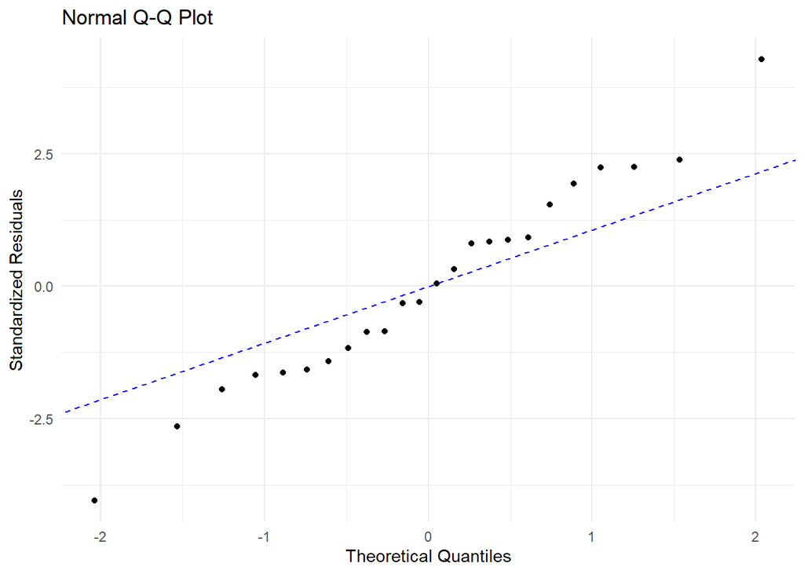

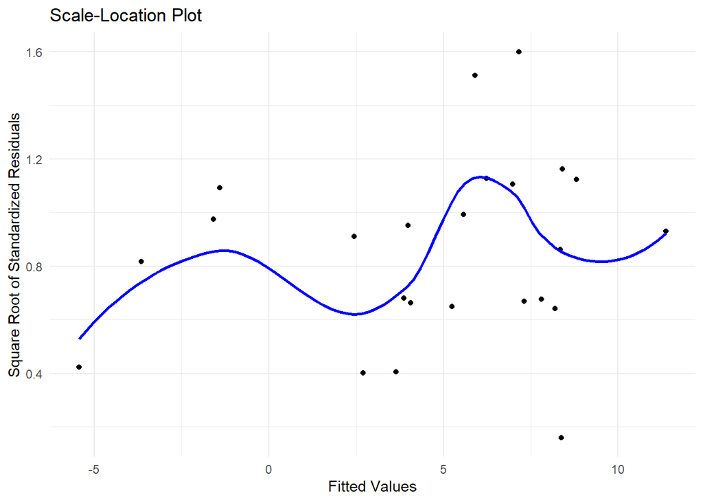

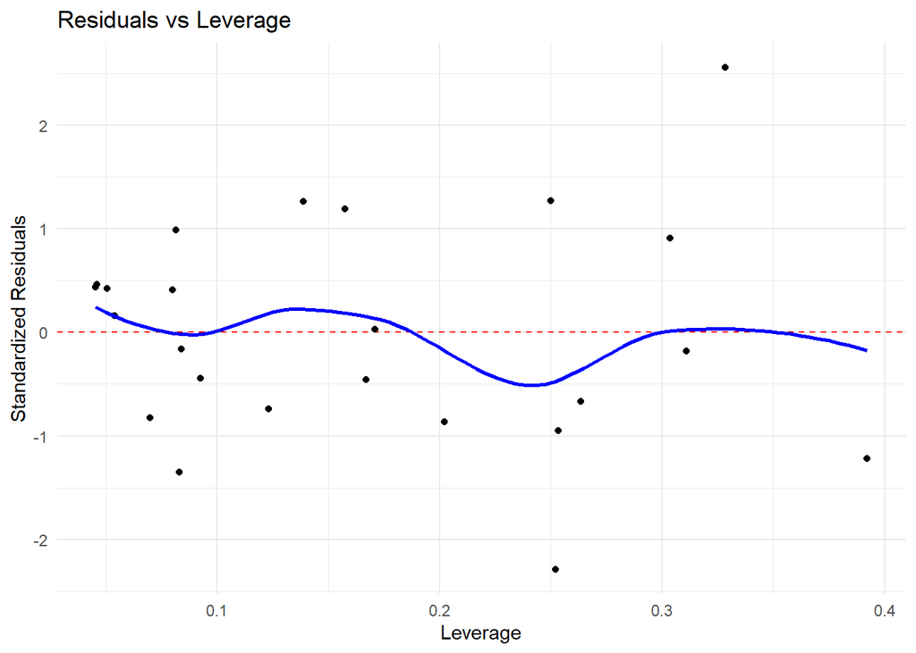

### Cook’s Distance

```
##  9 22 23
##  9 22 23
```

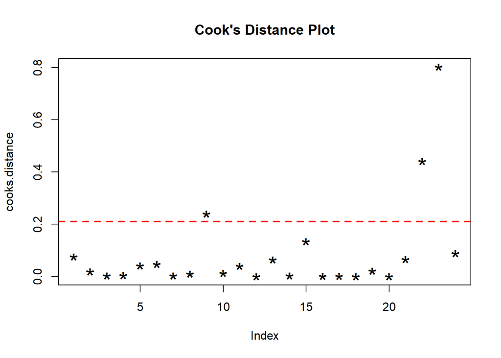

> Explanation: In this plot, while most points are within acceptable bounds, a few points significantly exceed the threshold, indicating they are outliers with substantial influence on the model.

## Conclusion

By identifying and addressing outliers, we improve the model’s accuracy and reliability, providing a sound basis for economic insights and decisions. Our analysis is based on the assumption that while most data points conform to a general trend, some may deviate due to various factors. Cook’s distance is a measure used to identify these influential outliers within the regression context.

The Cook’s Distance Plot shown illustrates the influence of each data point in a regression analysis. Data points with higher Cook’s Distance values are more influential, meaning they have a greater effect on the calculated regression line. The red dashed line represents a commonly used threshold; data points above this line are considered to have a significant impact and could potentially be outliers.

We use Cook’s Distance to identify such influential points because if they are the result of errors or special conditions not applicable to the rest of the dataset, they can distort the results of the analysis. Recognizing these points allows an analyst to make informed decisions about whether to include them in the analysis, which can lead to a more accurate and reliable model. In your plot, several points exceed the threshold, indicating they are influential and should be assessed further to maintain the integrity of your regression results. In our plot, several points exceed the threshold, indicating they are influential and should be assessed further to maintain the integrity of our regression results.